# Análise Bivariada - NYC Restaurants

Insper - Instituto de Ensino e Pesquisa

Lucas S. Macoris & Felipe G. Tomkowski

06/03/2020

## Sobre o documento

Este documento[^1] em *R Markdown* é o primeiro arquivo complementar relativo à disciplina de Microeconomia, compreendendo o conteúdo da **Atividade Prática Supervisionada (APS)**. Neste arquivo, utilizaremos os conceitos discutidos na **Aula 3 - Análise Bivariada de Dados** para analisar os dados relativos a uma pesquisa de mercado (*survey*) realizada em Nova York sobre características de restaurantes italianos.

Para reproduzir as análises aqui realizadas, você precisará ter instalado em seu computador o *R* ou o *RStudio*. Os computadores da biblioteca do Insper possuem instalados os programas acima mencionados. No entanto, caso você queira fazer diretamente de seu computador, você precisará instalar ambos os programas.

Você poderá fazer o *download* de forma gratuita do *R* através [deste link](https://cran.r-project.org/). Além disso, para fazer o *download* do RStudio, acesse [este link](https://rstudio.com/products/rstudio/) e clique no botão “Download RStudio Desktop”. Para a realização das análises, recomendamos que seja utilizado o *RStudio*, pelo fato de ser uma interface mais amigável para a reprodução dos códigos.

Para ter uma introdução básica de como utilizar o RStudio, recomendamos assistir a este pequeno vídeo clicando [neste link](https://www.youtube.com/watch?v=4j_rtffftzQ).

## Sobre a base de dados - NYC Restaurants

Analisaremos um conjunto de dados presentes em Sheather (2009)[^2] que contém informações sobre uma série de restaurantes italianos em Manhattan que foram abertos em 2001 (alguns deles estão fechados agora).

Os dados são coletados através do *Zagat Survey*, um guia de restaurantes e de entretenimento nas principais cidades norte-americanas, com destaque para a cidade de Nova York, criado e publicado a partir de 1979 por Tim e Nina Zagat. O guia tem por base uma pesquisa de opinião feita atravées de uma sondagem conduzida junto dos clientes dos restaurantes nova-iorquinos. Adicionamos também uma variável chamada `Age`, construída articialmente, para fins didáticos.

O sistema de classificação baseia-se numa escala de 25 pontos, cobrindo aspectos como a qualidade da comida, a decoração e ambiente do estabelecimento, o serviço e o preço. As variáveis presentes na base de dados são:

- `Restaurant`: nome do restaurante.
- `Price`: preço de uma refeição básica no restaurante (comida + bebida).
- `Food`: média das avaliações do restaurante no *Zagat Survey* para o quesito comida.
- `Decor`: média das avaliações do restaurante no *Zagat Survey* para o quesito decoração.
- `Service`: média das avaliações do restaurante no *Zagat Survey* para o quesito serviço.
- `East`: variável binária, apresentando o valor `1` se o restaurante fica no lado Leste de Manhattan, e zero caso contrário.
- `Age`: média da idade dos respondentes do restaurante no *Zagat Survey*.

## Análise Descritiva dos dados

A partir de agora, todo o conteúdo presente dentro das *chunk boxes* (área dentro do quadrado cinza) será relacionado à aplicação dos conceitos discutidos em aula. **Você poderá copiar e colar todo o código** presente dentro do referido espaço para reproduzir a análise por conta própria.

### 1. Carregando os dados

```r
#Vamos carregar o arquivo dentro do RStudio (você precisa colocá-lo no diretório que será indicado pela função getwd() - note que o diretório apresentado logo abaixo refere-se ao meu computador. Você precisa utilizar a função getwd() para verificar o diretório no seu computador.

getwd()
```

```
## [1] "C:/Users/Lucas/Google Drive/Monitoria - APS (Microeconomia) - Insper/R Markdown/Aula 3 - Análise Bivariada"
```

```r
#Colocando o arquivo NYC.csv no diretório que a função getwd() retornou a você, use a função read.csv para ler o documento e guardar numa base chamada Data:

Data<-read.csv('Restaurants.csv',header = TRUE,
                          stringsAsFactors = FALSE,
                          encoding = 'UTF-8',sep=';')


names(Data)[1]<-'Obs'
names(Data)[2]<-'Restaurant'


#Carrengando os pacotes necessários: aqui, você irá carregar as funcionalidades que precisamos:

#Intro: apresentando as estatísticas básicas da base de dados
summary(Data)
```

```
##       Obs          Restaurant            Price           Food
##  Min.   :  1.00   Length:168         Min.   :19.0   Min.   :16.0
##  1st Qu.: 42.75   Class :character   1st Qu.:36.0   1st Qu.:19.0
##  Median : 84.50   Mode  :character   Median :43.0   Median :20.5
##  Mean   : 84.50                      Mean   :42.7   Mean   :20.6
##  3rd Qu.:126.25                      3rd Qu.:50.0   3rd Qu.:22.0
##  Max.   :168.00                      Max.   :65.0   Max.   :25.0
##      Decor          Service          East            Age
##  Min.   : 6.00   Min.   :14.0   Min.   :0.000   Min.   :18.0
##  1st Qu.:16.00   1st Qu.:18.0   1st Qu.:0.000   1st Qu.:25.0
##  Median :18.00   Median :20.0   Median :1.000   Median :43.0
##  Mean   :17.69   Mean   :19.4   Mean   :0.631   Mean   :42.2
##  3rd Qu.:19.00   3rd Qu.:21.0   3rd Qu.:1.000   3rd Qu.:60.0
##  Max.   :25.00   Max.   :24.0   Max.   :1.000   Max.   :65.0
```

```r
#Intro: apresentando as 10 primeiras observações da base de dados:
head(Data,n=10)
```

```
##    Obs          Restaurant Price Food Decor Service East Age
## 1    1 Daniella Ristorante    43   22    18      20    0  26
## 2    2  Tello's Ristorante    32   20    19      19    0  23
## 3    3          Biricchino    34   21    13      18    0  25
## 4    4             Bottino    41   20    20      17    0  18
## 5    5          Da Umberto    54   24    19      21    0  42
## 6    6            Le Madri    52   22    22      21    0  45
## 7    7              Le Zie    34   22    16      21    0  60
## 8    8           Pasticcio    34   20    18      21    1  23
## 9    9             Belluno    39   22    19      22    1  18
## 10  10        Cinque Terre    44   21    17      19    1  26
```

### Correlação entre variáveis e gráficos de dispersão

1. Utilizando gráficos básicos do R

```r
#Vamos calcular a correlação entre as Variáveis Price, Service, Decor e food - variáveis 3,4,5 e 6)

cor(Data[,3:6])
```

```
##             Price      Food     Decor   Service
## Price   1.0000000 0.6270435 0.7243525 0.6411402
## Food    0.6270435 1.0000000 0.5039161 0.7945248
## Decor   0.7243525 0.5039161 1.0000000 0.6453306
## Service 0.6411402 0.7945248 0.6453306 1.0000000
```

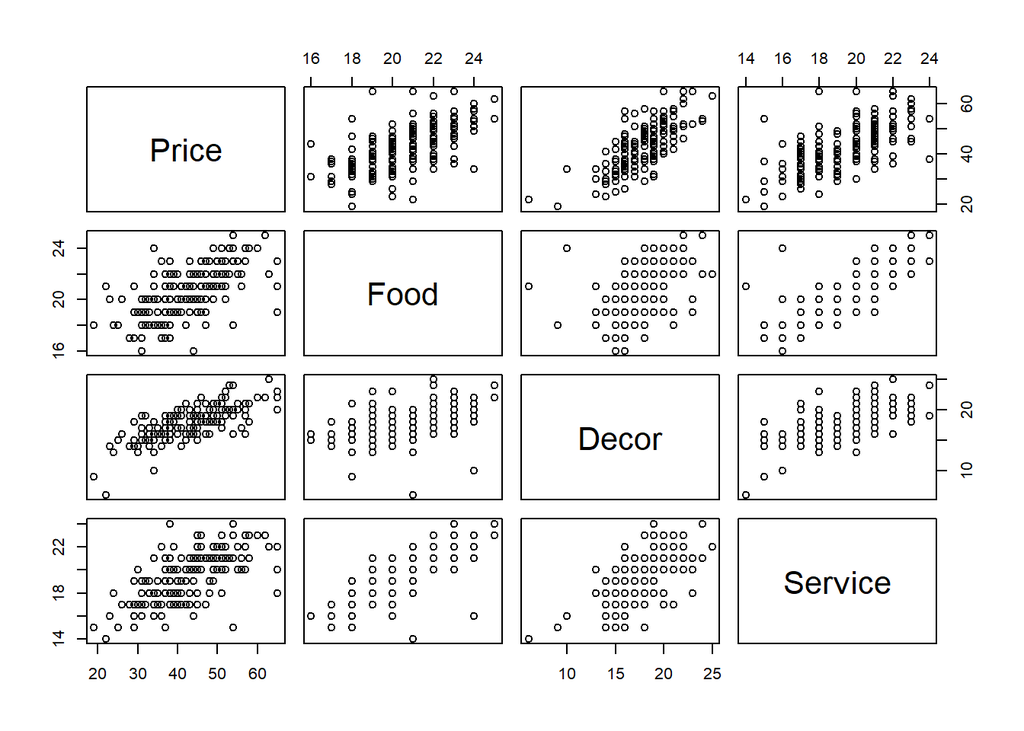

```r
#Também podemos visualizar a correlação de forma gráfica gerando todos os gráficos de dispersão de forma automática

pairs(Data[,3:6],)
```

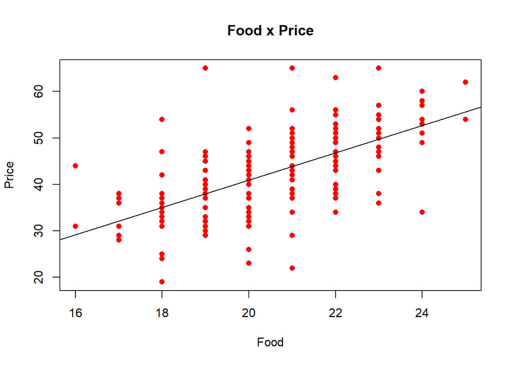

```r
#Gerando gráficos de dispersão um a um e adicionando a linha de tendência em cada caso:

plot(Data$Food,Data$Price,main='Food x Price',xlab='Food',ylab='Price',col='red',pch=16)
abline(lm(Price ~ Food,data=Data))
```

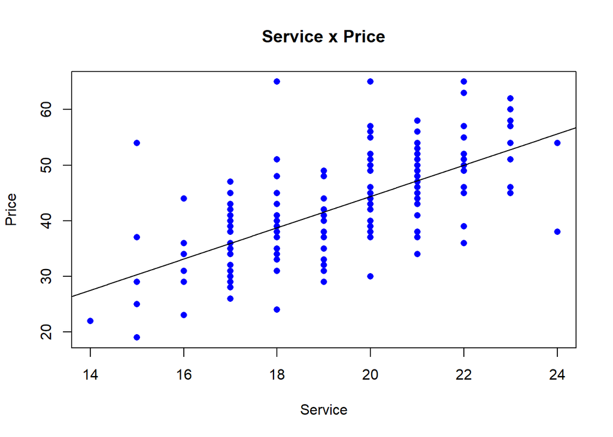

```r
plot(Data$Service,Data$Price,main='Service x Price',xlab='Service',ylab='Price',col='blue',pch=16)
abline(lm(Price ~ Service,data=Data))
```

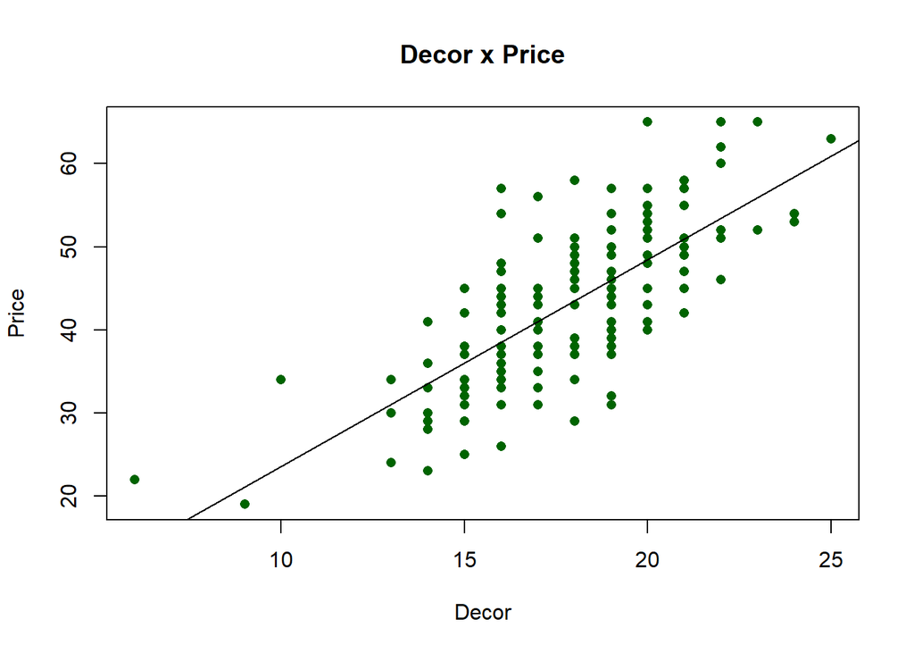

```r
plot(Data$Decor,Data$Price,main='Decor x Price',xlab='Decor',ylab='Price',col='darkgreen',pch=16)
abline(lm(Price ~ Decor,data=Data))
```

1. Utilizando o `ggplot2`

Dentro do R, temos uma série de funcionalidades pré-definidas, tal como no Excel. No entanto, a grande flexibilidade trazida pelo *R* (e também pelo *Python*) é a possibilidade de instalar **pacotes**, ou seja, novas funcionalidades para uma série de questões que queremos responder (ou responder de uma forma mais adequada).

Neste exemplo, veremos como podemos utilizar um dos pacotes mais famosos do R, o `ggplot2`, para criar uma visualização gráfica mais poderosa dos nossos dados. O `ggplot2` é um pacote de visualização de dados criado por Hadley Wickham em 2005. Tal pacote é uma implementação da **Grammar of Graphics** de Leland Wilkinson - um esquema geral para visualização de dados que divide gráficos em componentes semânticos, como escalas e camadas. O ggplot2 pode servir como um substituto para os gráficos base em R e contém vários padrões para exibição na Web e impressão de escalas comuns. Desde 2005, o ggplot2 cresceu para se tornar um dos pacotes R mais populares.

Antes de tudo, vamos verificar se temos o pacote `ggplot2` instalado em nosso computador. Caso contrário, iremos instalá-lo (este procedimento é o mesmo para qualquer outro pacote que você queira instalar no R).

```r
#Vamos verificar o GGPLOT como um pacote gráfico e instalar, caso necessário, junto com outros pacotes que nos serão úteis:
if (!require("ggplot2")) install.packages("ggplot2")
if (!require("GGally")) install.packages("GGally")
if (!require("ggpubr")) install.packages("ggpubr")
if (!require("ggcorrplot")) install.packages("ggcorrplot")


#Agora, precisamos carregá-lo em nossa sessão utilizando a função library():

library(ggplot2)
library(GGally)
library(ggpubr)
library(ggcorrplot)
```

Agora, vamos refazer os gráficos de dispersão e correlação utilizando as funções do pacote instalado.

1.1 Refazendo os gráficos de dispersão

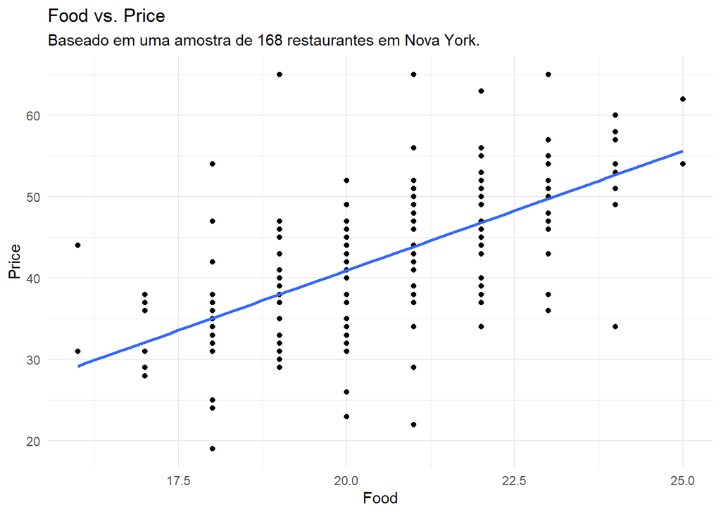

```r
#Vamos refazer os gráficos de dispersão para a variável Food
ggplot(data=Data,aes(x=Food,y=Price))+
#Gráfico de Dispersão
geom_point()+
#Adicionando uma linha de tendência
geom_smooth(method='lm',se=FALSE)+
#Legendas
labs(x='Food',y='Price',title='Food vs. Price',subtitle='Baseado em uma amostra de 168 restaurantes em Nova York.')+
#Tipo de tema: você pode mudar para uma série de temas (ex- theme_classic,theme_void,theme_gray,theme_bw, entre outros
theme_minimal()
```

Note que existem muitos pontos se sobrepondo entre si. Uma forma de melhorar a visualização é utilizando um parâmetro de “prenchimento” chamado `alpha`. Quanto menor o `alpha`, menos opacos ficam os pontos do gráfico! Além disso, usaremos a função `ggarrange` para inserir vários gráficos em uma mesma imagem.

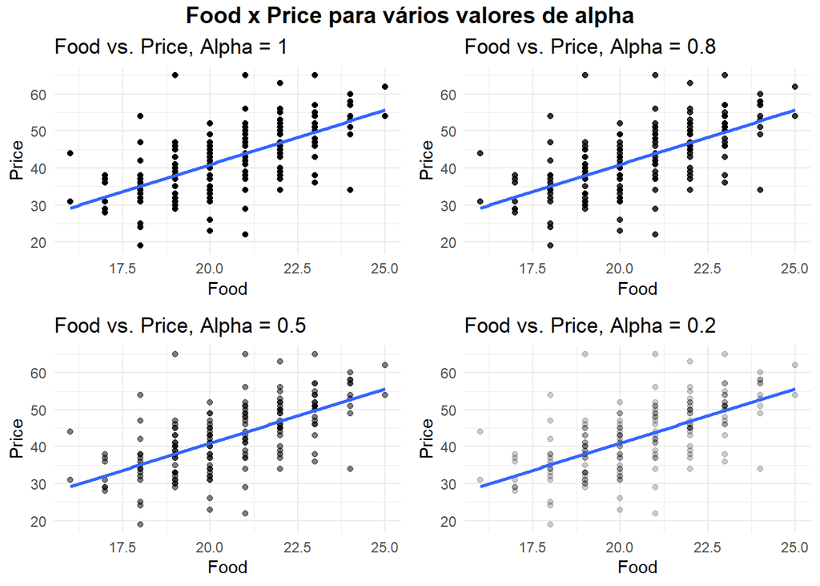

```r
#Vamos refazer os gráficos de dispersão para food, mudando os alphas. Para isso, vamos "guardar" os diferentes gráficos nos objetos A1,A3,A3 e A4.

A1<-ggplot(data=Data,aes(x=Food,y=Price))+
#Gráfico de Dispersão com alpha=1
geom_point(alpha=1)+
#Adicionando uma linha de tendência
geom_smooth(method='lm',se=FALSE)+
#Legendas
labs(x='Food',y='Price',title='Food vs. Price, Alpha = 1')+
#Tipo de tema: você pode mudar para uma série de temas (ex- theme_classic,theme_void,theme_gray,theme_bw, entre outros
theme_minimal()

A2<-ggplot(data=Data,aes(x=Food,y=Price))+
#Gráfico de Dispersão com alpha=1
geom_point(alpha=0.8)+
#Adicionando uma linha de tendência
geom_smooth(method='lm',se=FALSE)+
#Legendas
labs(x='Food',y='Price',title='Food vs. Price, Alpha = 0.8')+
#Tipo de tema: você pode mudar para uma série de temas (ex- theme_classic,theme_void,theme_gray,theme_bw, entre outros
theme_minimal()


A3<-ggplot(data=Data,aes(x=Food,y=Price))+
#Gráfico de Dispersão com alpha=1
geom_point(alpha=0.5)+
#Adicionando uma linha de tendência
geom_smooth(method='lm',se=FALSE)+
#Legendas
labs(x='Food',y='Price',title='Food vs. Price, Alpha = 0.5')+
#Tipo de tema: você pode mudar para uma série de temas (ex- theme_classic,theme_void,theme_gray,theme_bw, entre outros
theme_minimal()


A4<-ggplot(data=Data,aes(x=Food,y=Price))+
#Gráfico de Dispersão com alpha=1
geom_point(alpha=0.2)+
#Adicionando uma linha de tendência
geom_smooth(method='lm',se=FALSE)+
#Legendas
labs(x='Food',y='Price',title='Food vs. Price, Alpha = 0.2')+
#Tipo de tema: você pode mudar para uma série de temas (ex- theme_classic,theme_void,theme_gray,theme_bw, entre outros
theme_minimal()

#Agora, vamos adicioná-los todos juntos em uma imagem 2x2
Grafico<-ggarrange(A1,A2,A3,A4,ncol=2,nrow=2)
#Plotando o gráfico com título
annotate_figure(Grafico,
               top = text_grob("Food x Price para vários valores de alpha", face = "bold", size = 14))
```

Como podemos verificar, mudar o valor de `alpha` para valores mais próximos de zero aumenta a transparência dos pontos, de forma que pontos **mais escuros** refletem maior concentração de valores. Isso nos ajuda a identificar alguns padrões em gráficos onde temos uma série de valores repetidos para os pares ordenados $(x,y)$.

O que mais podemos fazer com o `ggplot`? Podemos adicionar uma série de incrementos no gráfico para enfatizar **outras** variáveis. Por exemplo, podemos **colorir** os pontos de acordo com uma terceira variável, `East`, por exemplo, ao adicionar um parâmetro chamado `col`. Ou seja, iremos preencher os pontos de acordo com os valores dados pela variável `East`:

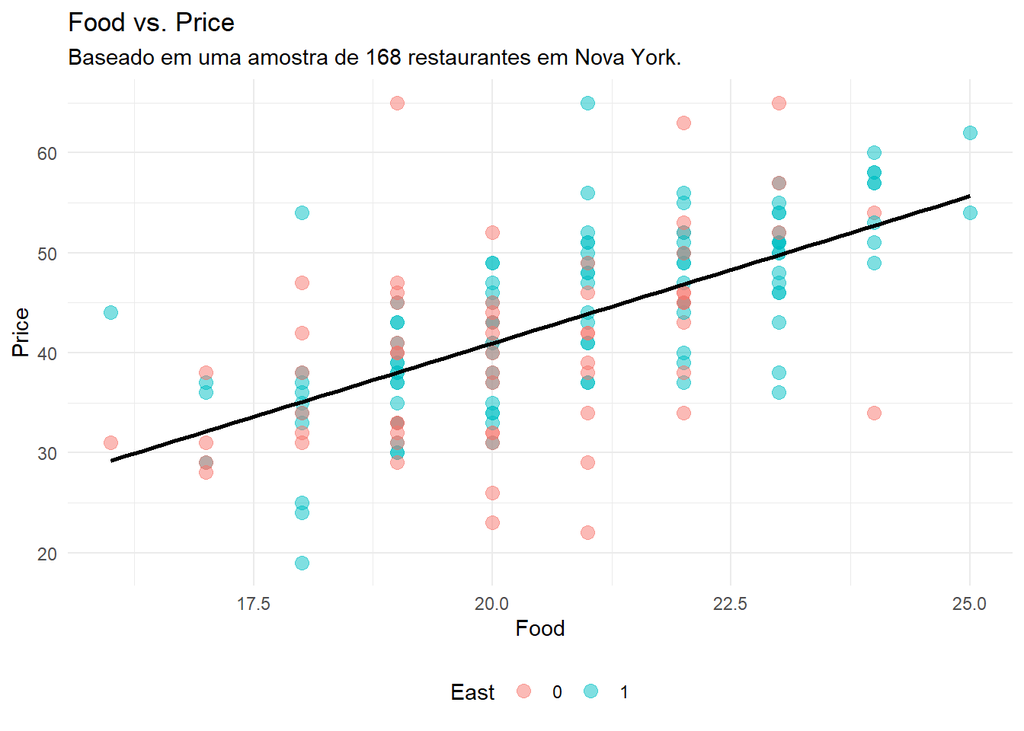

```r
ggplot(data=Data,aes(x=Food,y=Price))+
#Adicionamos aqui o parâmetro  col
geom_point(aes(col=factor(East)),alpha=0.5,size=3)+
#Adicionando uma linha de tendência
geom_smooth(data=Data,aes(x=Food,y=Price,group = 1),method='lm',se=FALSE,col='black')+
#Legendas
labs(x='Food',y='Price',
     title='Food vs. Price',
     subtitle='Baseado em uma amostra de 168 restaurantes em Nova York.',
     col='East')+
#Tipo de tema: você pode mudar para uma série de temas (ex- theme_classic,theme_void,theme_gray,theme_bw, entre outros
theme_minimal()+
theme(legend.position = 'bottom')
```

Alternativamente, podemos facetar o gráfico através da função `facet_wrap`:

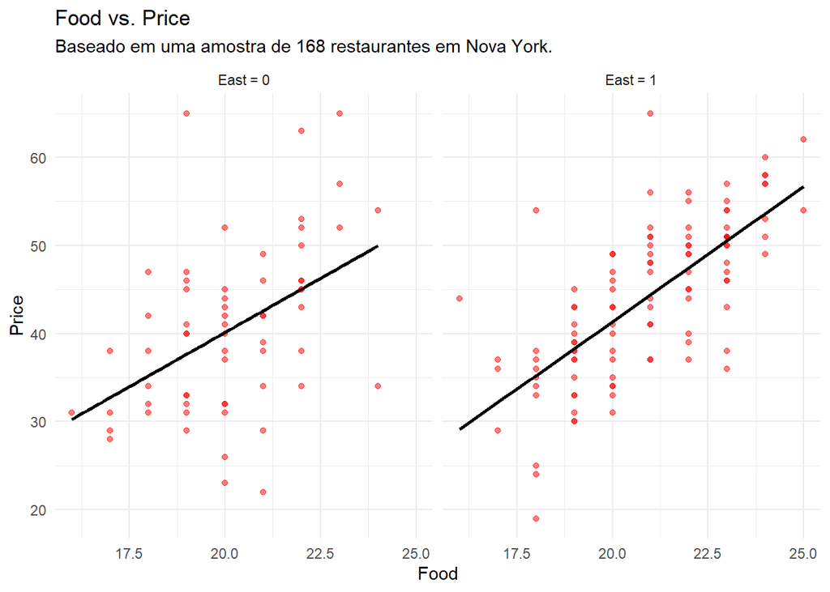

```r
ggplot(data=Data,aes(x=Food,y=Price))+
#Adicionamos aqui o parâmetro  col
geom_point(alpha=0.5,col='red')+
#Adicionando uma linha de tendência
geom_smooth(data=Data,aes(x=Food,y=Price,group = 1),method='lm',se=FALSE,col='black')+
#Legendas
labs(x='Food',y='Price',
     title='Food vs. Price',
     subtitle='Baseado em uma amostra de 168 restaurantes em Nova York.',
     col='East')+
#Tipo de tema: você pode mudar para uma série de temas (ex- theme_classic,theme_void,theme_gray,theme_bw, entre outros
theme_minimal()+
theme(legend.position = 'bottom')+

#Facetamos de acordo com a variável East
facet_wrap(~East,
           labeller=labeller(
                   East=c("0"="East = 0",
                          "1"="East = 1")))
```

Vamos, portanto, vamos fazer um gráfico de dispersão da variável `Price` com cada uma das variáveis `Food`, `Decor` e `Service`, colorindo os pontos de acordo com a variável `East`, adicionando uma linha de tendência em cada gráfico:

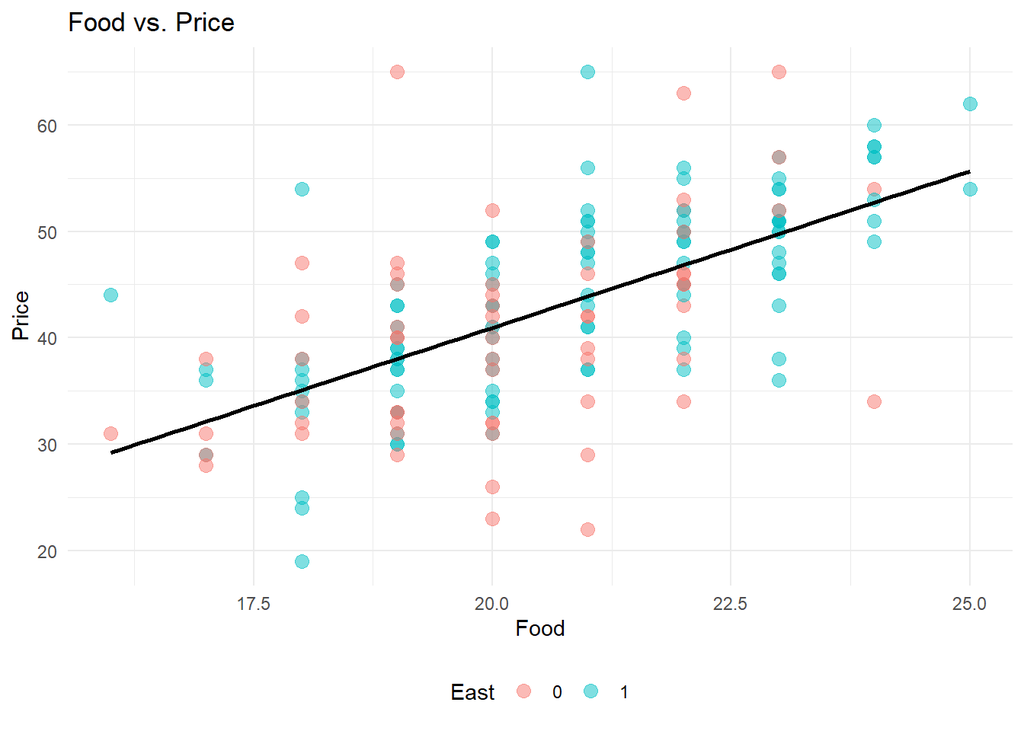

```r
##########Food

G1<-ggplot(data=Data,aes(x=Food,y=Price))+
#Adicionamos aqui o parâmetro  col
geom_point(aes(col=factor(East)),alpha=0.5,size=3)+
#Adicionando uma linha de tendência
geom_smooth(data=Data,aes(x=Food,y=Price,group = 1),method='lm',se=FALSE,col='black')+
#Legendas
labs(x='Food',y='Price',
     title='Food vs. Price',
     col='East')+
#Tipo de tema: você pode mudar para uma série de temas (ex- theme_classic,theme_void,theme_gray,theme_bw, entre outros
theme_minimal()+
theme(legend.position = 'bottom')

G1
```

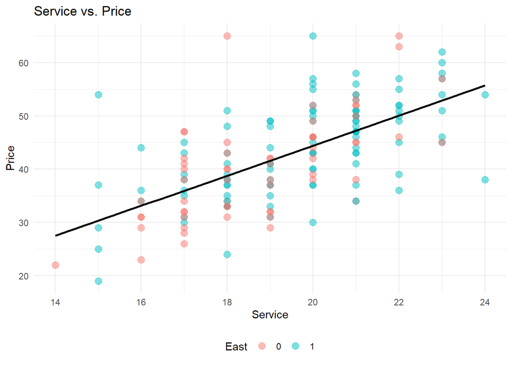

```r
##########Service

G2<-ggplot(data=Data,aes(x=Service,y=Price))+
#Adicionamos aqui o parâmetro  col
geom_point(aes(col=factor(East)),alpha=0.5,size=3)+
#Adicionando uma linha de tendência
geom_smooth(data=Data,aes(x=Service,y=Price,group = 1),method='lm',se=FALSE,col='black')+
#Legendas
labs(x='Service',y='Price',
     title='Service vs. Price',
     col='East')+
#Tipo de tema: você pode mudar para uma série de temas (ex- theme_classic,theme_void,theme_gray,theme_bw, entre outros
theme_minimal()+
theme(legend.position = 'bottom')

G2
```

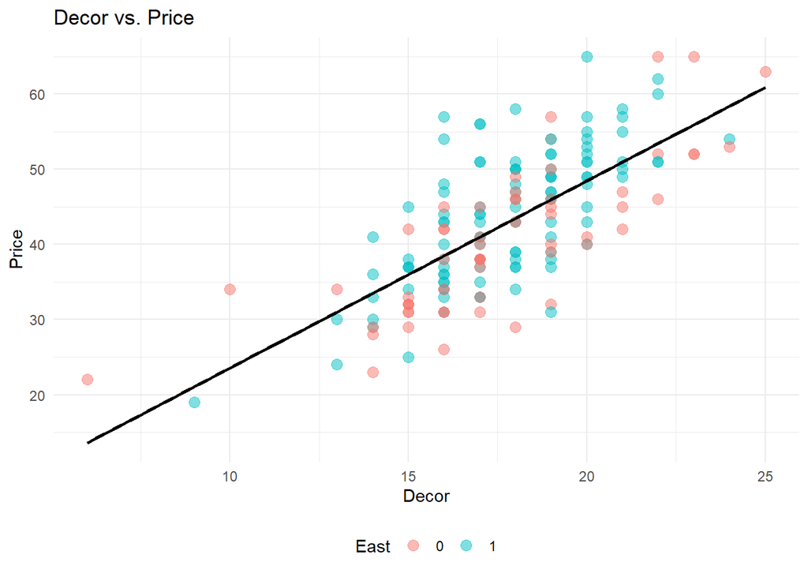

```r
##########Decor

G3<-ggplot(data=Data,aes(x=Decor,y=Price))+
#Adicionamos aqui o parâmetro  col
geom_point(aes(col=factor(East)),alpha=0.5,size=3)+
#Adicionando uma linha de tendência
geom_smooth(data=Data,aes(x=Decor,y=Price,group = 1),method='lm',se=FALSE,col='black')+
#Legendas
labs(x='Decor',y='Price',
     title='Decor vs. Price',
     col='East')+
#Tipo de tema: você pode mudar para uma série de temas (ex- theme_classic,theme_void,theme_gray,theme_bw, entre outros
theme_minimal()+
theme(legend.position = 'bottom')

G3
```

1.2 Refazendo as correlações

Utilizamos a função `cor()` para calcular a correlação entre todas as quatro variáveis consideradas no nosso estudo. No entanto, a visualização gerada é de uma matriz básica, onde existem vários valores repetidos. Como podemos melhorar a análise?

Vamos utilizar a função `ggpairs` para gerar uma visualização que irá contemplar a distribuição da variável (similar a um histograma), bem como cada uma das correlações entre as quatro variáveis:

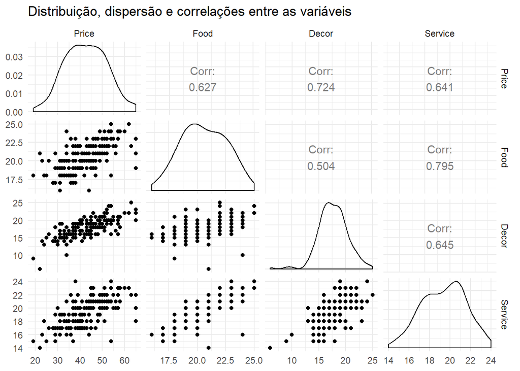

```r
ggpairs(Data[,3:6])+
        labs(title='Distribuição, dispersão e correlações entre as variáveis')+
        theme_minimal()
```

Note que, agora, temos uma série de análises **em um só gráfico**, além de não termos mais os números das correlações dos pares $(x,y)$ duplicadas (já que $Cor(x,y)=Cor(y,x)$. Adicionamos, nas diagonais, onde a correlação seria **1**, a distribuição da variável em questão, enquanto que ao invés de repetir o índice de correlação abaixo e acima da diagonal principal devido à simetria da correlação, colocamos, de um lado, o gráfico de dispersão das variáveis, enquanto que do outro, o índice de correlação de cada par.

Por fim, uma outra forma bem interessante de apresentar, de forma resumida, as correlações presentes em nossa base de dados, é possível utilizar a função `ggcorrplot`, que irá sintetizar as associações entre as variáveis de uma forma mais intuitiva:

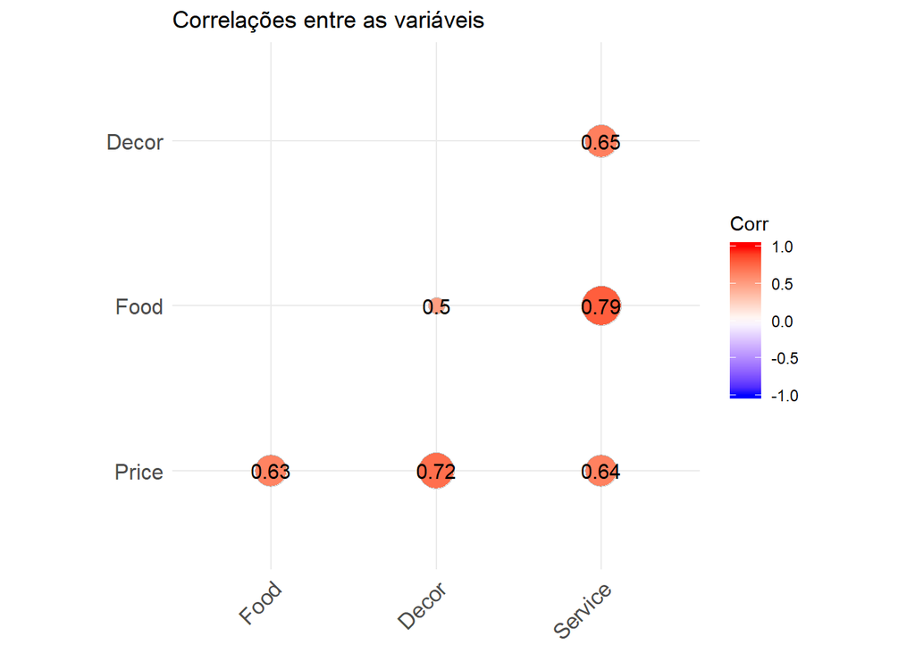

```r
G4<-ggcorrplot(cor(Data[,3:6]), method = "circle",
           title = 'Correlações entre as variáveis',
           type='lower',lab=TRUE)

G4
```

Note que, para cada par de variáveis $(x,y)$, a função irá apresentar o índice de correlação (que está sempre entra **-1** e **1**, bem como irá criar um círculo de tamanho correspondende ao **grau** de associação das variáveis: conforme maior o tamanho do círculo, maior é a correlação. Adicionalmente, como vimos em sala, além do grau de associação entre as variáveis, precisamos analisar outro componente da correlação, que o **sinal** (ou direção) da associação. A função `ggcorrplot`, conforme a legenda indica, pinta de vermelho as correlações positiva entre as variáveis, e de azul as negativas.

Vemos, portanto, que nos dados apresentamos, possuímos somente correlações positivas entre as variáveis, sendo que as variáveis com maior nível de associação linear são *Service* e *Food*!

Por fim, vamos fazer um gráfico de dispersão da variável `Price` com cada uma das variáveis `Food`, `Decor` e `Service`, colorindo os pontos de acordo com a variável `East`, adicionando uma linha de tendência em cada gráfico e plotando todos dentro de uma mesma imagem juntamente com o gráfico de correlação gerado pela função `ggcorrplot`.

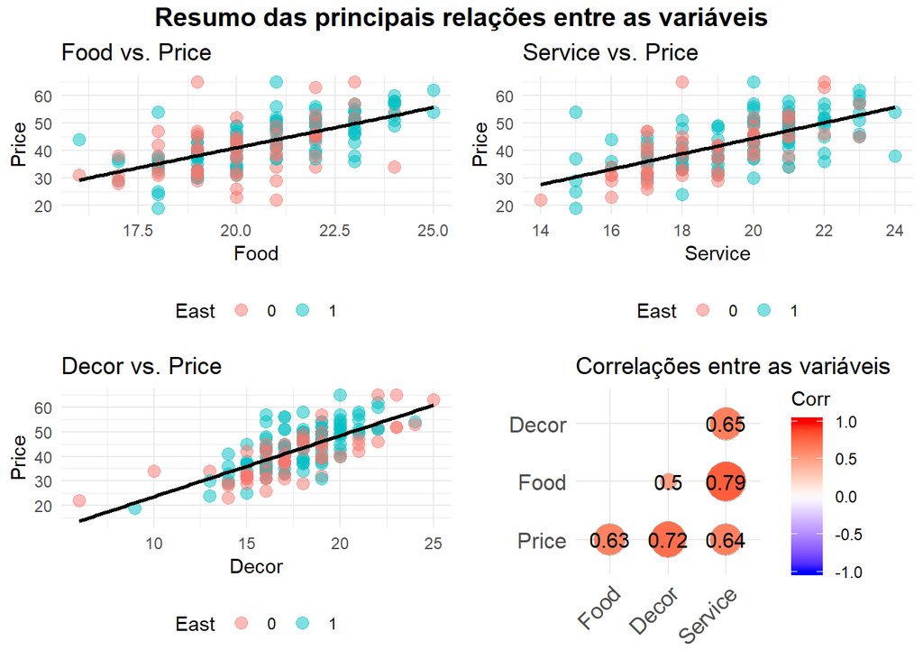

```r
Resumo<-ggarrange(G1,G2,G3,G4,ncol=2,nrow=2)
#Plotando o gráfico com título
annotate_figure(Resumo,
               top = text_grob("Resumo das principais relações entre as variáveis", face = "bold", size = 14))
```

3. Relação entre preço e idade

É de se esperar que a relação entre preço e idade não seja **perfeitamente** linear: ou seja, é normal verificarmos que, conforme saímos da adolescência e começamos a trabalhar, a renda irá aumentar e, consequentemente, o consumo também tenderá a aumentar. No entanto, também é intuitivo pensar que, após certa idade, nosso consumo tende a diminuir, seja por questões de renda, como também por outras variáveis, como a mudança de hábitos.

Neste sentido, vamos verificar a relação entre as variáveis *Price* e *Age* dentro de nosso banco de dados:

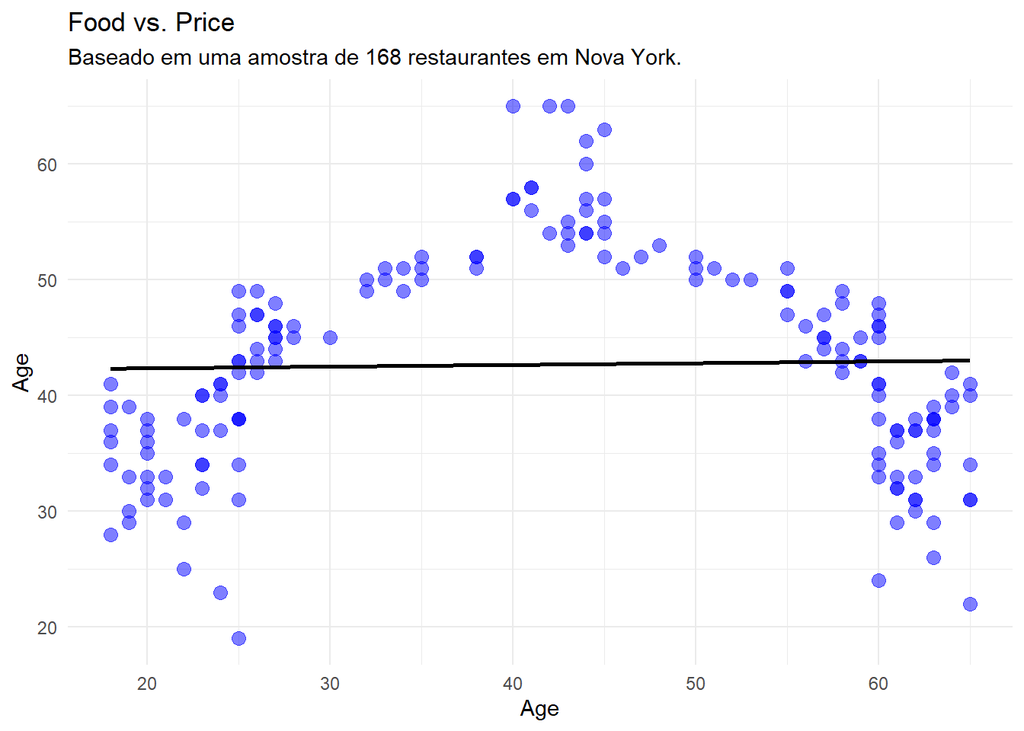

```r
ggplot(data=Data,aes(x=Age,y=Price))+
#Adicionamos aqui o parâmetro  col
geom_point(alpha=0.5,size=3,col='blue')+
#Adicionando uma linha de tendência
geom_smooth(data=Data,aes(x=Age,y=Price,group = 1),method='lm',se=FALSE,col='black')+
#Legendas
labs(x='Age',y='Age',
     title='Food vs. Price',
     subtitle='Baseado em uma amostra de 168 restaurantes em Nova York.')+
#Tipo de tema: você pode mudar para uma série de temas (ex- theme_classic,theme_void,theme_gray,theme_bw, entre outros
theme_minimal()+
theme(legend.position = 'bottom')
```

Note que o gráfico cria uma linha de tendência praticamente horizontal, enquanto que os pares ordenados se distribuem de uma forma totalmente distinta. Se calcularmos o coeficiente de correlação, veremos que ele é muito pequeno:

```r
cor(Data$Price,Data$Age)
```

```
## [1] 0.02635484
```

Isso significa dizer que **não há relação entre Preço e Idade**? Não! O fato da correlação ser baixa significa, tão somente, de que a **associação linear** entre as variáveis é muito baixa! Claramente, como vemos, a relação entre *Price* e *Age* parece ser de uma forma quadrática: existe uma função de segundo grau que pode descrever, de forma satisfatória, a relação entre as duas varíaveis. Como esperávamos, o preço médio gasto nos restaurantes começa a crescer após sairmos da adolescência, mas cresce cada vez menos, até chegar em uma idade (neste caso, aproximadamente 40-43 anos) **onde a tendência se inverte**: o consumo, para cada ano a mais de idade, em média, tende a cair!

Vamos repetir o gráfico acima, mas ao invés de traçar uma **linha** de tendência, vamos pedir ao **R** para tentar **adivinhar** algum outro tipo de relação entre as variáveis:

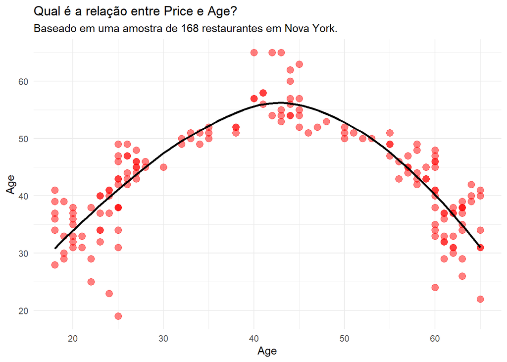

```r
ggplot(data=Data,aes(x=Age,y=Price))+
#Adicionamos aqui o parâmetro  col
geom_point(alpha=0.5,size=3,col='red')+
#Adicionando uma linha de tendência
geom_smooth(data=Data,aes(x=Age,y=Price,group = 1),method='loess',se=FALSE,col='black')+
#Legendas
labs(x='Age',y='Age',
     title='Qual é a relação entre Price e Age?',
     subtitle='Baseado em uma amostra de 168 restaurantes em Nova York.')+
#Tipo de tema: você pode mudar para uma série de temas (ex- theme_classic,theme_void,theme_gray,theme_bw, entre outros
theme_minimal()+
theme(legend.position = 'bottom')
```

Conforme esperávamos, vemos que a relação entre as duas variáveis é uma relação **não-linear** (neste caso, uma relação de segundo grau). Ou seja, mesmo que a correlação entre duas variáveis seja baixa, isso não significa que elas não estejam relacionadas!

[^1]: Este material foi elaborado para a utilização como conteúdo complementar da disciplina de Microeconomia dos cursos de graduação em Administração e Economia do **Insper - Instituto de Ensino e Pesquisa**. Para maiores informações, entre em contato com os responsáveis através de lucassm4@al.insper.edu.br ou felipegt1@al.insper.edu.br.
[^2]: Sheather, Simon. A modern approach to regression with R. Springer Science & Business Media, 2009.